# Graphics

## Graphics

- base: old system
- lattice: creating function to plot
- ggplot2: standard
- ggvis: in progress

## Base

- example of a base graphics

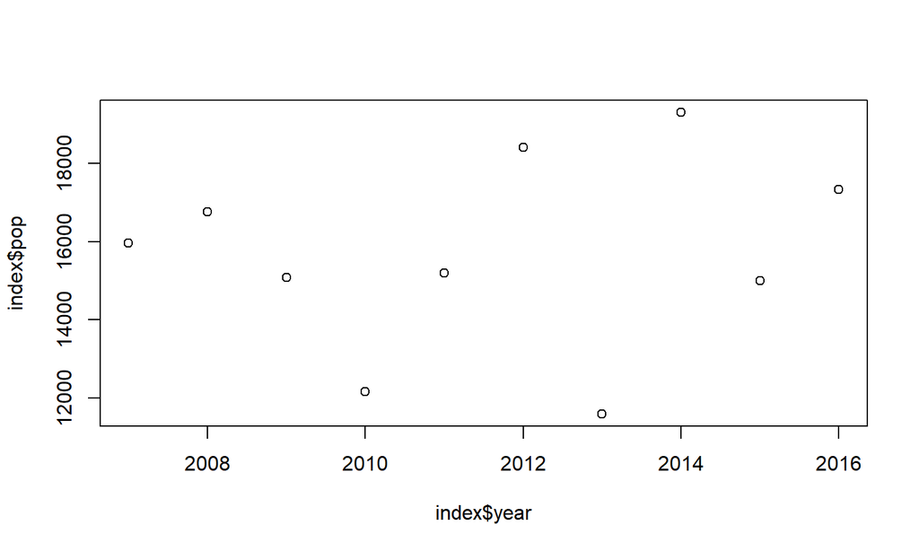

```r
index<-data.frame(year=2007:2016, pop=sample(10000:20000, size=10))

plot(index$year,index$pop)
```

## Base - lines

- type lines

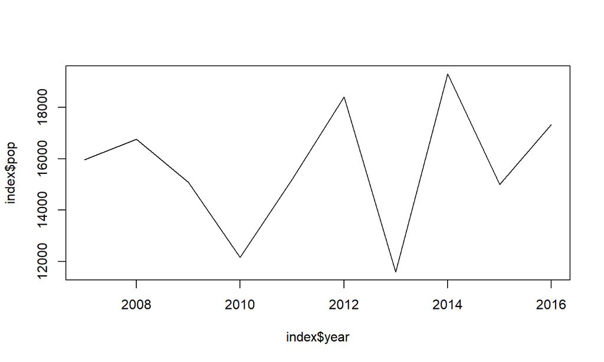

```r
#lines
plot(index$year,index$pop, type="l")
```

## Base - histrogram

- type histogram

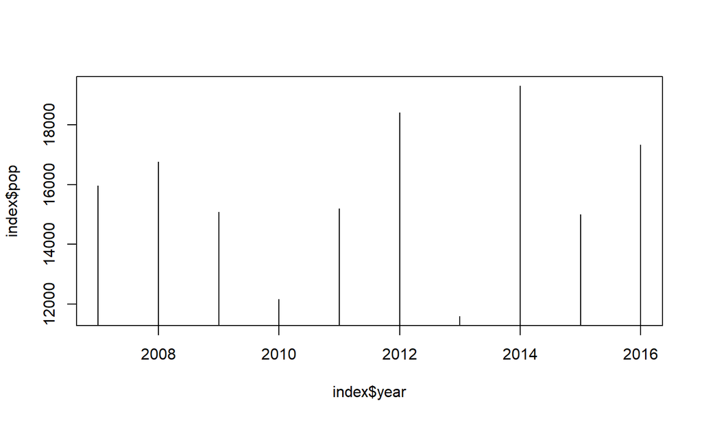

```r
plot(index$year,index$pop, type="h")
```

## Base - title and axis labels

- adding title and axis labels

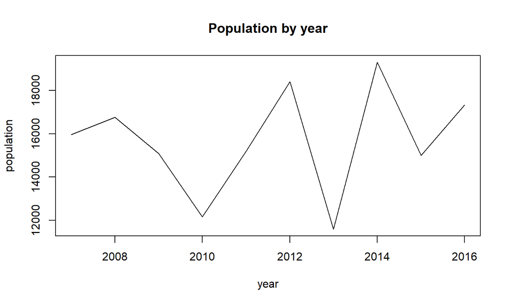

```r
plot(index$year,index$pop, type="l", main="Population by year",
     xlab="year",ylab="population")
```

## Lab

- use mtcars dataset and create a line plot where cyl must be on x axis and mean mpg on y axis

## Lattice - creating a function

- pop~year or mean mpg~cyl

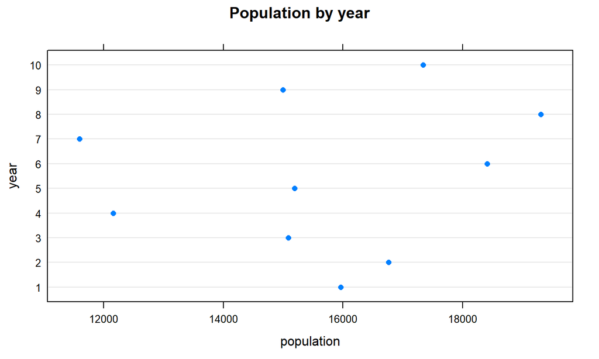

```r
lattice::dotplot(year~pop,data=index,main="Population by year",
        ylab="year",xlab="population")
```

## Lattice - problem with y-values

- we must change year values to factors

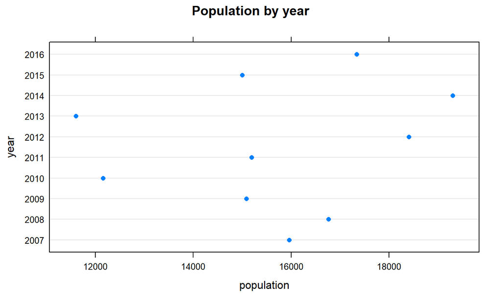

```r
index$year<-as.factor(index$year)
lattice::dotplot(year~pop,data=index,main="Population by year",
        ylab="year",xlab="population")
```

## Lattice - histrogram

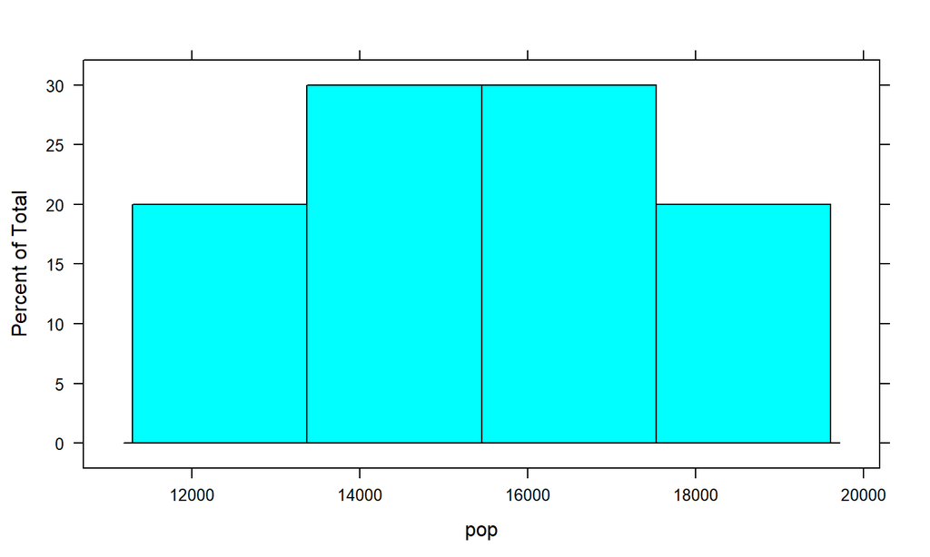

```r
histogram(year~pop,data=index)
```

## Lattice - more complex formula

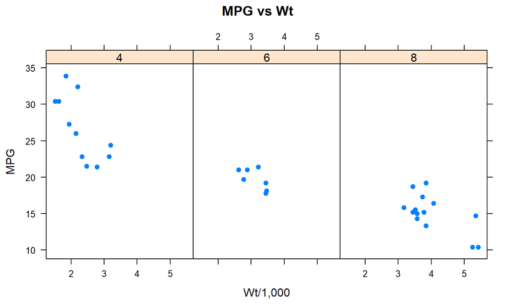

```r
xyplot(mpg~wt | factor(cyl), data=mtcars, pch=19,
                main="MPG vs Wt", xlab="Wt/1,000",  ylab="MPG")
```

## Lab

- use mtcars dataset and create a barchart of mean mpg for number of gears per cyl

## ggplot2

- input data (data.frame)
- aes - color, format and size
- geoms - geometric objects (points, lines, …)
- facets - forms a matrix of panels defined by row and column faceting variable
- stats - statistical transformations
- scales

## ggplot2 - basic object

- ggplot(data, aes(x,y))
- geom_bar()
- geom_point()
- geom_line()

## ggplot2 - adding metadata

- ggtitle()
- xlab()
- ylab()

## ggplot2 - example

- line chart

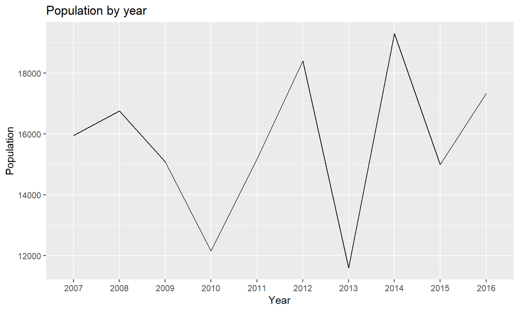

```r
g<-ggplot(index,aes(x=year,y=pop, group=1))+geom_line()
g<-g+ggtitle("Population by year")+xlab("Year")+ylab("Population")
g
```

## ggplot2 - additional options in aes part

- fill: colour of data in a barchar

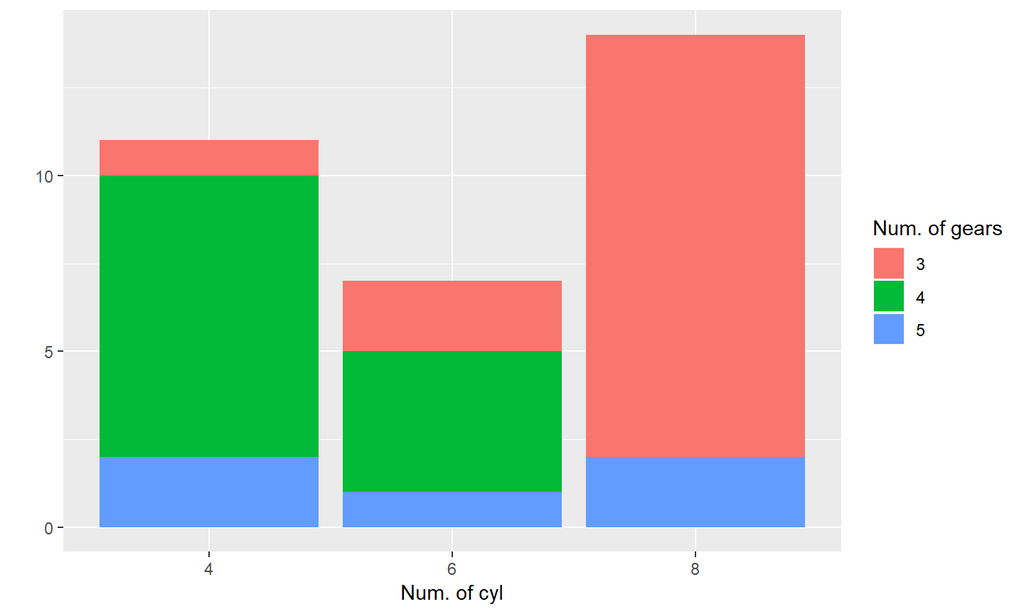

```r
ggplot(data=mtcars, aes(x=as.factor(cyl), fill=factor(gear))) +
  geom_bar()+xlab("Num. of cyl")+ylab("")+labs(fill="Num. of gears")
```

## ggplot2 - setting axis limits+changing stat function

- we already have data aggregated, so we have to use stat="identity"
- xlim, ylim specify the range of scale

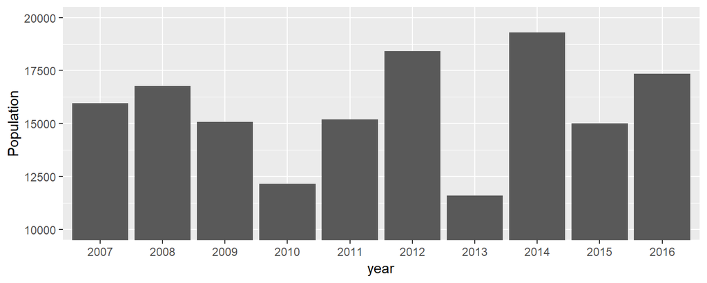

```r
ggplot(index,aes(x=as.factor(year), y=pop))+geom_bar(stat="identity")+
  coord_cartesian(ylim=c(10000,20000))+ylab("Population")+xlab("year")
```

## ggplot2 - themes

- few themes in ggplot2 package
- for more install ggthemes package

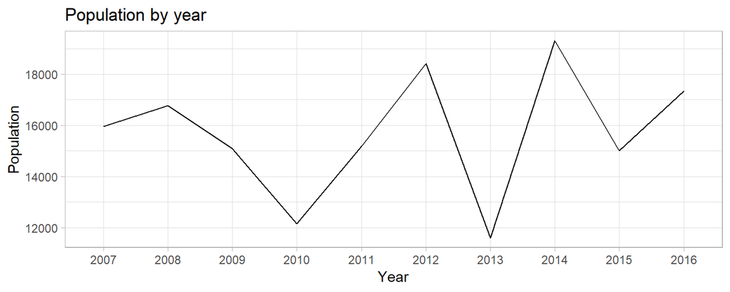

```r
g<-g+theme_light()

g
```

## ggplot2 - themes (1)

- if labels are messy, use rotation
- axis.text.x = element_text(angle = 60, hjust = 1)

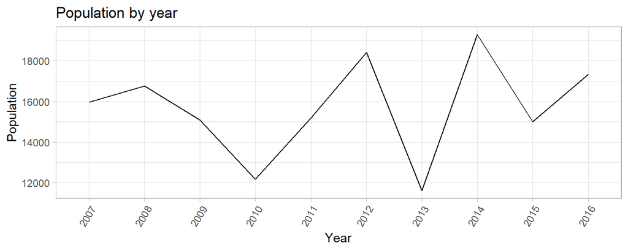

```r
g<-g+theme(axis.text.x = element_text(angle = 60, hjust = 1))

g
```

## Lab

- create barchar with cyl on x axis, number of cars

## ggplot2 - rotation

-coord_flip()

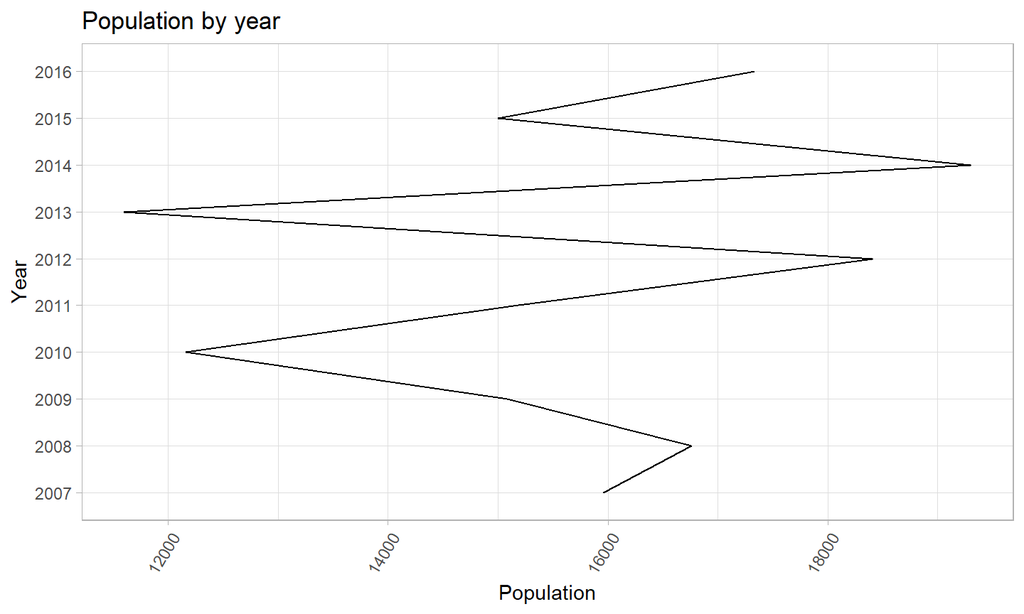

```r
g<-g+coord_flip()

g
```

## ggplot2 - facet_grid()

- adding 1 or 2 additional variables
- facet_grid(variable1~.)
- facet_grid(.~variable1)
- facet_grid(variable1~variable2)

## ggplot2 - facet_grid() (1)

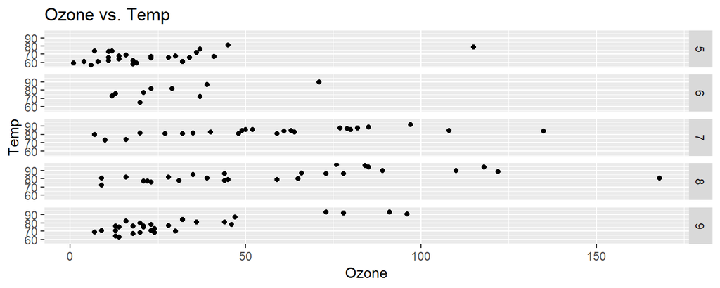

```r
g<- ggplot(airquality, aes(x=Ozone, y=Temp))+geom_point()
g<-g+ggtitle("Ozone vs. Temp")+facet_grid(Month~.)
g
```

## ggplot2 - geom_smooth()(1)

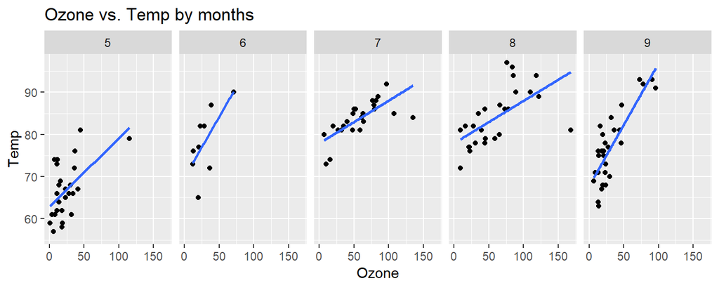

```r
g<-g+facet_grid(.~Month)+ggtitle("Ozone vs. Temp by months")
g<-g+geom_smooth(method = lm, se = FALSE)
g
```

## Lab

- create chart "Ozone vs. Temp by months", where temperatures will be in Celsius. Search for transformation formula online.

## Adding vertical and horizontal lines

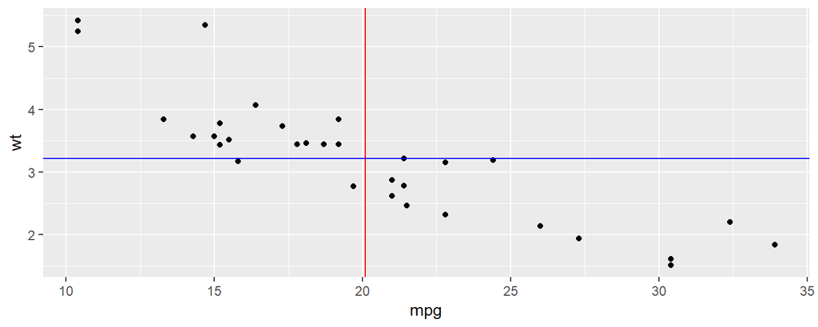

```r
ggplot(data=mtcars, aes(x=mpg, y=wt)) + geom_point() +
geom_vline(xintercept=mean(mtcars$mpg), col="red")+
geom_hline(yintercept=mean(mtcars$wt), col="blue")
```

## Lab

- create scatter chart "Ozone vs. Temp by months", where temperatures will be in Celsius
- add mean ozone and mean temp lines and interpet the results

## Adding more than one chart onto single ggplot object

- I would like to get the combinaton of geom_point() and geom_box()

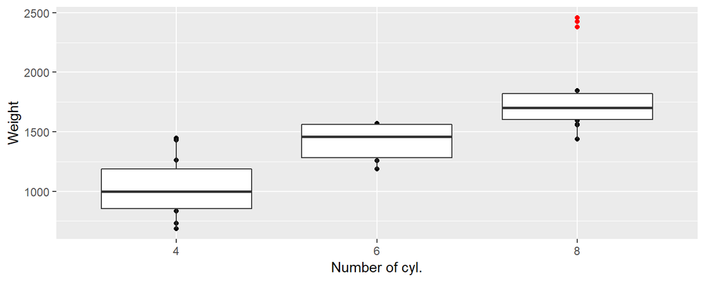

```r
ggplot(data=mtcars, aes(x=as.factor(cyl), y=wt*1000/2.205)) + geom_point()+
  xlab("Number of cyl.")+ylab("Weight")+geom_boxplot(outlier.color = "red")
```

## Lab

- use iris data set. Combine geom_point and box_plot to produce a chart of Petal.Length for every Species. Identify outliers with blue color.

## gridExtra (1)

- package gridExtra
- it allows you to combine many charts side by side

```r
g<- ggplot(airquality, aes(x=Ozone, y=Temp))+geom_point()
g<-g+ggtitle("Ozone vs. Temp")
y<- ggplot(index,aes(x=year,y=pop, group=1))+geom_line()
y<-y+ggtitle("Population by year")+xlab("Year")+ylab("Population")
```

## gridExtra (2)

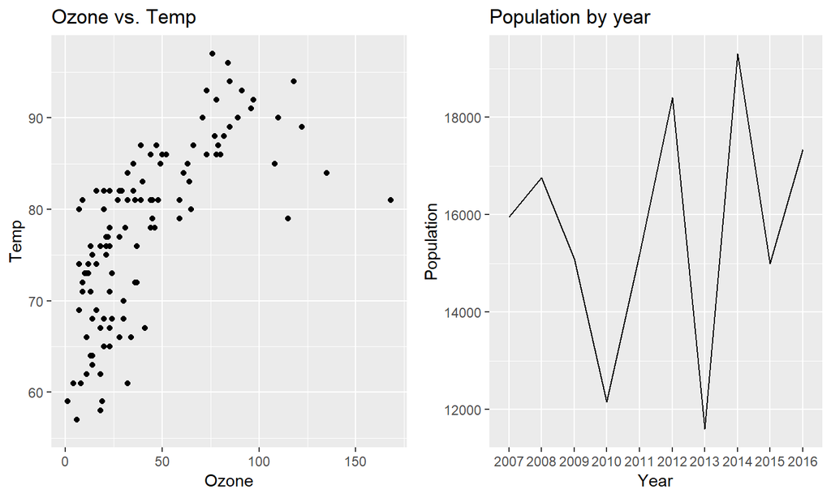

```r
grid.arrange(g, y, ncol=2)
```

## Lab

- use Titanic dataset
- create two charts side by side
- first chart should have number of survived/dead passengers by age
- second chart should have number of survived/dead passengers by class